# Improving metabolite identification with MetaNetX

Workshop 18JS-RFMF · SIB Swiss Institute of Bioinformatics

Author

Florence Mehl

Published

May 13, 2026

**NoteHow to use this document**

This document is **pre-rendered**: all SPARQL queries have already been executed.

- Code is collapsed by default
- Use the **</> Code** button to expand
- Reflection questions are highlighted

If you want to **run the code**, install R packages once:

```r
install.packages(c("sparqlr","readxl","dplyr","tidyr","stringr",
                   "igraph","visNetwork","ggplot2","knitr","kableExtra"))
```

# 1 Introduction

## 1.1 Metabolites in MetaNetX

Metabolic networks databases consist of metabolites that act as substrates and products of biochemical reactions. However, there exists numerous inconsistencies in name or chemical structures within the different databases, and through their cross-references.

The MetaNetX algorithm reconciles chemical-entity identifiers according to structural information, reaction context, and, to a lesser extent, cross-references and names from source databases.**In MetaNetX, metabolites are defined as sets of chemical-entity identifiers that are considered equivalent**. Within a set, chemical entities may interconvert via spontaneous reactions—such as acid–base reaction or tautomerism — which spontaneously takes place in aqueous solution (as in cellular metabolism). In addition, entities participating in enzymatically catalyzed reactions are systematically assigned to distinct sets and considered distinct metabolites.

## 1.2 Why correctly identify metabolites?

In metabolomics, the same chemical entity can have dozens of different identifiers depending on the database used. Without reconciliation, two analyses of the same metabolite may appear to involve different entities — and vice versa.

[MetaNetX](https://www.metanetx.org/) aggregates identifiers from **KEGG, ChEBI, HMDB, BiGG, SEED, VMH, MetaCyc, Rhea, SABIO-RK**, and groups them into **sets** based on :

1. Chemical structure (MOL, SMILES, InChI)
2. Reaction context
3. Cross-references
4. Names

Each set receives a unique `MNXM` identifier. This identifier is useful for curation purposes but **is NOT stable across MetaNetX versions and should not be used as a persistent identifier**. Relationships between sets are modeled with `mnx:chemIsom`: a generic entity (e.g., *alanine*, without stereochemistry) points to its specific isomers (e.g., *L-alanine*, *D-alanine*).

# 2 Exercise 1 — ID Mapper : retrieving cross-database identifiers

## 2.1 Context

You are given a list of identifiers from **different databases**, all supposed to represent *alanine* in different forms. The goal is to submit them to MetaNetX and observe how they are grouped. Use MetaNetX ID-mapper available at https://www.metanetx.org/map/ids.

## 2.2 Input identifiers

```r
# identifiers list

input_ids_ex1 <- c(
  "chebi:16449",
  "chebi:32439",
  "chebi:66916",
  "chebi:143534",
  "chebi:132498",
  "chebi:32440",
  "hmdb:HMDB0062251",
  "keggC:C01401"
)

cat(paste(input_ids_ex1, collapse = "\n"))
```

```
chebi:16449
chebi:32439
chebi:66916
chebi:143534
chebi:132498
chebi:32440
hmdb:HMDB0062251
keggC:C01401
```

## 2.3 SPARQL query — mapping to MetaNetX

Strategy: a single query using a VALUES block to inject all identifiers. MetaNetX stores cross-references via `mnx:chemXref`, where the external identifier is carried in its `rdfs:label`. This query can also be run in the SPARQL editor available at: https://rdf.metanetx.org/

```r
MNX_ENDPOINT <- "https://rdf.metanetx.org/sparql"

query_ex1 <- '
PREFIX mnx:  <https://rdf.metanetx.org/schema/>
PREFIX rdfs: <http://www.w3.org/2000/01/rdf-schema#>

SELECT DISTINCT ?query_id ?mnx_id ?name ?inchikey
WHERE {
  VALUES ?query_id {
    "chebi:16449"
    "chebi:32439"
    "chebi:66916"
    "chebi:143534"
    "chebi:132498"
    "chebi:32440"
    "hmdb:HMDB0062251"
    "keggC:C01401"
  }

  ?mnx_chem mnx:chemXref ?xref .
  ?xref     rdfs:label   ?query_id .
  ?mnx_chem rdfs:label   ?mnx_id .

  OPTIONAL { ?mnx_chem rdfs:comment  ?name     . }
  OPTIONAL { ?mnx_chem mnx:inchikey  ?inchikey . }
}
ORDER BY ?mnx_id
'

results_ex1 <- sparql_select(endpoint = MNX_ENDPOINT, query = query_ex1)
```

## 2.4 Results

```r
results_ex1 %>%
  mutate(mnx_id = sub(".*[/#]", "", mnx_id)) %>%
  select(query_id, mnx_id, name, inchikey) %>%
  mutate(mnx_id = mnx_link(mnx_id)) %>%
  kable(caption = "Table 1 — Identifiers mapping to MetaNetX", format = "html", escape = FALSE) %>%
  kable_styling(bootstrap_options = c("striped", "hover", "condensed"))
```

Table 1 — Identifiers mapping to MetaNetX

| query_id | mnx_id | name | inchikey |
| --- | --- | --- | --- |
| chebi:132498 | MNXM733981 | alanine | QNAYBMKLOCPYGJ-UHFFFAOYSA-N |
| chebi:143534 | MNXM733981 | alanine | QNAYBMKLOCPYGJ-UHFFFAOYSA-N |
| chebi:16449 | MNXM733981 | alanine | QNAYBMKLOCPYGJ-UHFFFAOYSA-N |
| chebi:32439 | MNXM733981 | alanine | QNAYBMKLOCPYGJ-UHFFFAOYSA-N |
| chebi:32440 | MNXM733981 | alanine | QNAYBMKLOCPYGJ-UHFFFAOYSA-N |
| chebi:66916 | MNXM733981 | alanine | QNAYBMKLOCPYGJ-UHFFFAOYSA-N |
| hmdb:HMDB0062251 | MNXM733981 | alanine | QNAYBMKLOCPYGJ-UHFFFAOYSA-N |
| keggC:C01401 | MNXM733981 | alanine | QNAYBMKLOCPYGJ-UHFFFAOYSA-N |

```r
res1 <- results_ex1 %>%
  mutate(mnx_id = sub(".*[/#]", "", mnx_id))

cat("Submitted identifiers  :", length(input_ids_ex1), "\n")
```

```
Submitted identifiers  : 8
```

```r
cat("Distinct MNX entities  :", n_distinct(res1$mnx_id), "\n")
```

```
Distinct MNX entities  : 1
```

**TipReflection questions — Exercise 1**

1. How many distinct MetaNetX entities correspond to the 8 identifiers?
2. Several identifiers map to the **same MNX set** — which ones? What does this imply for a dataset that contains these identifiers as separate features?
3. Are the identifiers `chebi:66916` (*alanine zwitterion*) and `chebi:16449` (*alanine*) in the same set? Why or why not?

# 3 Exercise 2 — Isomer relationships: from generic to specific

## 3.1 Context

MetaNetX distinguishes **generic entities** (e.g., *alanine* without stereochemistry) from **stereochemically specific entities** (*L-alanine*, *D-alanine*). The `mnx:chemIsom` relationship links a generic set to its specific isomers.

> **Why is this important for data quality?**  
> If your dataset contains both generic *alanine* and *L-alanine* in separate columns, you potentially introduce redundancy — but they are not exactly the same compound either. It is essential to know which one was actually measured.

Map the list of alanine identifiers using the MetaNetX ID mapper, the SPARQL editor, or the sparqlr R package, and examine the results.Then, retrieve the MNX reference sets associated with the alanine identifiers and analyse their isomer relationships.

In the MetaNetX knowledge graph, isomer relationships between chemical entities are represented by the predicate `mnx:chemIsom`.

## 3.2 Input identifiers — complete alanine family

```r
# Full list: all alanine family identifiers
# (alanine no stereo + L-alanine + D-alanine)
input_ids_ex2 <- c(
  # alanine no stereo (generic)
  "chebi:16449", "chebi:32439", "chebi:66916", "chebi:143534",
  "chebi:132498", "chebi:32440", "hmdb:HMDB0062251", "keggC:C01401",
  # L-alanine
  "chebi:16977", "chebi:57972", "chebi:229589", "chebi:32431",
  "chebi:76050", "chebi:32432", "keggD:D00012", "keggC:C00041",
  "biggM:ala__L", "hmdb:HMDB0000161", "sabiorkM:67", "seedM:cpd00035",
  "vmhM:ala_L", "metacycM:L-ALPHA-ALANINE",
  # D-alanine
  "chebi:57416", "chebi:32435", "chebi:15570", "chebi:32436",
  "biggM:ala__D", "hmdb:HMDB0001310", "sabiorkM:1940",
  "keggC:C00133", "seedM:cpd00117", "vmhM:ala_D", "metacycM:D-ALANINE"
)

cat(paste(input_ids_ex2, collapse = "\n"))
```

```
chebi:16449
chebi:32439
chebi:66916
chebi:143534
chebi:132498
chebi:32440
hmdb:HMDB0062251
keggC:C01401
chebi:16977
chebi:57972
chebi:229589
chebi:32431
chebi:76050
chebi:32432
keggD:D00012
keggC:C00041
biggM:ala__L
hmdb:HMDB0000161
sabiorkM:67
seedM:cpd00035
vmhM:ala_L
metacycM:L-ALPHA-ALANINE
chebi:57416
chebi:32435
chebi:15570
chebi:32436
biggM:ala__D
hmdb:HMDB0001310
sabiorkM:1940
keggC:C00133
seedM:cpd00117
vmhM:ala_D
metacycM:D-ALANINE
```

## 3.3 SPARQL query with isomer relationship

```r
# Pure SPARQL query — can be used directly in MetaNetX SPARQL editor
# (https://rdf.metanetx.org/).
query_ex2 <- '
PREFIX mnx:  <https://rdf.metanetx.org/schema/>
PREFIX rdfs: <http://www.w3.org/2000/01/rdf-schema#>

SELECT DISTINCT
  ?query_id ?mnx_chem ?mnx_id ?name
  ?chem_Isom ?chem_Isom_id ?chem_Isom_name
  ?inchikey
WHERE {
  VALUES ?query_id {
    # alanine no stereo (generic)
    "chebi:16449" "chebi:32439" "chebi:66916" "chebi:143534"
    "chebi:132498" "chebi:32440" "hmdb:HMDB0062251" "keggC:C01401"
    # L-alanine
    "chebi:16977" "chebi:57972" "chebi:229589" "chebi:32431"
    "chebi:76050" "chebi:32432" "keggD:D00012" "keggC:C00041"
    "biggM:ala__L" "hmdb:HMDB0000161" "sabiorkM:67" "seedM:cpd00035"
    "vmhM:ala_L" "metacycM:L-ALPHA-ALANINE"
    # D-alanine
    "chebi:57416" "chebi:32435" "chebi:15570" "chebi:32436"
    "biggM:ala__D" "hmdb:HMDB0001310" "sabiorkM:1940"
    "keggC:C00133" "seedM:cpd00117" "vmhM:ala_D" "metacycM:D-ALANINE"
  }

  ?mnx_chem mnx:chemXref ?xref .
  ?xref     rdfs:label   ?query_id .
  ?mnx_chem rdfs:label   ?mnx_id .

  OPTIONAL { ?mnx_chem rdfs:comment  ?name     . }
  OPTIONAL { ?mnx_chem mnx:inchikey  ?inchikey . }

  OPTIONAL {
    ?mnx_chem   mnx:chemIsom  ?chem_Isom .
    ?chem_Isom  rdfs:label    ?chem_Isom_id .
    OPTIONAL { ?chem_Isom rdfs:comment ?chem_Isom_name . }
  }
}
ORDER BY ?query_id
'

results_ex2_raw <- sparql_select(endpoint = MNX_ENDPOINT, query = query_ex2)
```

## 3.4 Results cleaning

```r
results_ex2 <- results_ex2_raw %>%
  mutate(
    mnx_id       = sub(".*[/#]", "", mnx_id),
    chem_Isom_id = sub(".*[/#]", "", chem_Isom_id)
  ) %>%
  select(query_id, mnx_id, name, chem_Isom_id, chem_Isom_name, inchikey)

results_ex2 %>%
  mutate(
    mnx_id       = mnx_link(mnx_id),
    chem_Isom_id = mnx_link(chem_Isom_id, color = "#E07B39")
  ) %>%
  kable(caption = "Table 2 — Full mapping with isomeric relationships", format = "html", escape = FALSE) %>%
  kable_styling(bootstrap_options = c("striped", "hover", "condensed"))
```

Table 2 — Full mapping with isomeric relationships

| query_id | mnx_id | name | chem_Isom_id | chem_Isom_name | inchikey |
| --- | --- | --- | --- | --- | --- |
| biggM:ala__D | MNXM1105731 | D-alanine | NA | NA | QNAYBMKLOCPYGJ-UWTATZPHSA-N |
| biggM:ala__L | MNXM1105732 | L-alanine | NA | NA | QNAYBMKLOCPYGJ-REOHCLBHSA-N |
| chebi:132498 | MNXM733981 | alanine | MNXM1105731 | D-alanine | QNAYBMKLOCPYGJ-UHFFFAOYSA-N |
| chebi:132498 | MNXM733981 | alanine | MNXM1105732 | L-alanine | QNAYBMKLOCPYGJ-UHFFFAOYSA-N |
| chebi:143534 | MNXM733981 | alanine | MNXM1105731 | D-alanine | QNAYBMKLOCPYGJ-UHFFFAOYSA-N |
| chebi:143534 | MNXM733981 | alanine | MNXM1105732 | L-alanine | QNAYBMKLOCPYGJ-UHFFFAOYSA-N |
| chebi:15570 | MNXM1105731 | D-alanine | NA | NA | QNAYBMKLOCPYGJ-UWTATZPHSA-N |
| chebi:16449 | MNXM733981 | alanine | MNXM1105731 | D-alanine | QNAYBMKLOCPYGJ-UHFFFAOYSA-N |
| chebi:16449 | MNXM733981 | alanine | MNXM1105732 | L-alanine | QNAYBMKLOCPYGJ-UHFFFAOYSA-N |
| chebi:16977 | MNXM1105732 | L-alanine | NA | NA | QNAYBMKLOCPYGJ-REOHCLBHSA-N |
| chebi:229589 | MNXM1105732 | L-alanine | NA | NA | QNAYBMKLOCPYGJ-REOHCLBHSA-N |
| chebi:32431 | MNXM1105732 | L-alanine | NA | NA | QNAYBMKLOCPYGJ-REOHCLBHSA-N |
| chebi:32432 | MNXM1105732 | L-alanine | NA | NA | QNAYBMKLOCPYGJ-REOHCLBHSA-N |
| chebi:32435 | MNXM1105731 | D-alanine | NA | NA | QNAYBMKLOCPYGJ-UWTATZPHSA-N |
| chebi:32436 | MNXM1105731 | D-alanine | NA | NA | QNAYBMKLOCPYGJ-UWTATZPHSA-N |
| chebi:32439 | MNXM733981 | alanine | MNXM1105731 | D-alanine | QNAYBMKLOCPYGJ-UHFFFAOYSA-N |
| chebi:32439 | MNXM733981 | alanine | MNXM1105732 | L-alanine | QNAYBMKLOCPYGJ-UHFFFAOYSA-N |
| chebi:32440 | MNXM733981 | alanine | MNXM1105731 | D-alanine | QNAYBMKLOCPYGJ-UHFFFAOYSA-N |
| chebi:32440 | MNXM733981 | alanine | MNXM1105732 | L-alanine | QNAYBMKLOCPYGJ-UHFFFAOYSA-N |
| chebi:57416 | MNXM1105731 | D-alanine | NA | NA | QNAYBMKLOCPYGJ-UWTATZPHSA-N |
| chebi:57972 | MNXM1105732 | L-alanine | NA | NA | QNAYBMKLOCPYGJ-REOHCLBHSA-N |
| chebi:66916 | MNXM733981 | alanine | MNXM1105731 | D-alanine | QNAYBMKLOCPYGJ-UHFFFAOYSA-N |
| chebi:66916 | MNXM733981 | alanine | MNXM1105732 | L-alanine | QNAYBMKLOCPYGJ-UHFFFAOYSA-N |
| chebi:76050 | MNXM1105732 | L-alanine | NA | NA | QNAYBMKLOCPYGJ-REOHCLBHSA-N |
| hmdb:HMDB0000161 | MNXM1105732 | L-alanine | NA | NA | QNAYBMKLOCPYGJ-REOHCLBHSA-N |
| hmdb:HMDB0001310 | MNXM1105731 | D-alanine | NA | NA | QNAYBMKLOCPYGJ-UWTATZPHSA-N |
| hmdb:HMDB0062251 | MNXM733981 | alanine | MNXM1105731 | D-alanine | QNAYBMKLOCPYGJ-UHFFFAOYSA-N |
| hmdb:HMDB0062251 | MNXM733981 | alanine | MNXM1105732 | L-alanine | QNAYBMKLOCPYGJ-UHFFFAOYSA-N |
| keggC:C00041 | MNXM1105732 | L-alanine | NA | NA | QNAYBMKLOCPYGJ-REOHCLBHSA-N |
| keggC:C00133 | MNXM1105731 | D-alanine | NA | NA | QNAYBMKLOCPYGJ-UWTATZPHSA-N |
| keggC:C01401 | MNXM733981 | alanine | MNXM1105731 | D-alanine | QNAYBMKLOCPYGJ-UHFFFAOYSA-N |
| keggC:C01401 | MNXM733981 | alanine | MNXM1105732 | L-alanine | QNAYBMKLOCPYGJ-UHFFFAOYSA-N |
| keggD:D00012 | MNXM1105732 | L-alanine | NA | NA | QNAYBMKLOCPYGJ-REOHCLBHSA-N |
| metacycM:D-ALANINE | MNXM1105731 | D-alanine | NA | NA | QNAYBMKLOCPYGJ-UWTATZPHSA-N |
| metacycM:L-ALPHA-ALANINE | MNXM1105732 | L-alanine | NA | NA | QNAYBMKLOCPYGJ-REOHCLBHSA-N |
| sabiorkM:1940 | MNXM1105731 | D-alanine | NA | NA | QNAYBMKLOCPYGJ-UWTATZPHSA-N |
| sabiorkM:67 | MNXM1105732 | L-alanine | NA | NA | QNAYBMKLOCPYGJ-REOHCLBHSA-N |
| seedM:cpd00035 | MNXM1105732 | L-alanine | NA | NA | QNAYBMKLOCPYGJ-REOHCLBHSA-N |
| seedM:cpd00117 | MNXM1105731 | D-alanine | NA | NA | QNAYBMKLOCPYGJ-UWTATZPHSA-N |
| vmhM:ala_D | MNXM1105731 | D-alanine | NA | NA | QNAYBMKLOCPYGJ-UWTATZPHSA-N |
| vmhM:ala_L | MNXM1105732 | L-alanine | NA | NA | QNAYBMKLOCPYGJ-REOHCLBHSA-N |

## 3.5 Summary : one line per MNX entity

```r
summary_ex2 <- results_ex2 %>%
  group_by(mnx_id, name, chem_Isom_id, chem_Isom_name) %>%
  summarise(
    n_input_ids = n(),
    input_ids   = paste(query_id, collapse = " · "),
    .groups = "drop"
  ) %>%
  arrange(is.na(chem_Isom_id), mnx_id)

cat("Distinct MNX entities           :", n_distinct(results_ex2$mnx_id), "\n")
```

```
Distinct MNX entities           : 3
```

```r
cat("Entities with specific isomer(s)  :",
    sum(!is.na(summary_ex2$chem_Isom_id[!duplicated(summary_ex2$mnx_id)])), "\n")
```

```
Entities with specific isomer(s)  : 1
```

```r
summary_ex2 %>%
  mutate(
    mnx_id       = mnx_link(mnx_id),
    chem_Isom_id = mnx_link(chem_Isom_id, color = "#E07B39")
  ) %>%
  kable(caption = "Table 3 — One line per MNX entity (with input identifier)",
        format = "html", escape = FALSE) %>%
  kable_styling(bootstrap_options = c("striped", "hover", "condensed"))
```

Table 3 — One line per MNX entity (with input identifier)

| mnx_id | name | chem_Isom_id | chem_Isom_name | n_input_ids | input_ids |
| --- | --- | --- | --- | --- | --- |
| MNXM733981 | alanine | MNXM1105731 | D-alanine | 8 | chebi:132498 · chebi:143534 · chebi:16449 · chebi:32439 · chebi:32440 · chebi:66916 · hmdb:HMDB0062251 · keggC:C01401 |
| MNXM733981 | alanine | MNXM1105732 | L-alanine | 8 | chebi:132498 · chebi:143534 · chebi:16449 · chebi:32439 · chebi:32440 · chebi:66916 · hmdb:HMDB0062251 · keggC:C01401 |
| MNXM1105731 | D-alanine | NA | NA | 11 | biggM:ala__D · chebi:15570 · chebi:32435 · chebi:32436 · chebi:57416 · hmdb:HMDB0001310 · keggC:C00133 · metacycM:D-ALANINE · sabiorkM:1940 · seedM:cpd00117 · vmhM:ala_D |
| MNXM1105732 | L-alanine | NA | NA | 14 | biggM:ala__L · chebi:16977 · chebi:229589 · chebi:32431 · chebi:32432 · chebi:57972 · chebi:76050 · hmdb:HMDB0000161 · keggC:C00041 · keggD:D00012 · metacycM:L-ALPHA-ALANINE · sabiorkM:67 · seedM:cpd0… |

## 3.6 Detection of duplicates

```r
dupes <- results_ex2 %>%
  group_by(mnx_id) %>%
  summarise(
    n_ids     = n_distinct(query_id),
    query_ids = paste(unique(query_id), collapse = " · "),
    name      = first(name),
    .groups   = "drop"
  ) %>%
  filter(n_ids > 1) %>%
  arrange(desc(n_ids))

if (nrow(dupes) > 0) {
  dupes %>%
    mutate(mnx_id = mnx_link(mnx_id)) %>%
    kable(caption = "⚠️ Multiple identifiers mapping to the same MNX entity",
          format = "html", escape = FALSE) %>%
    kable_styling(bootstrap_options = c("striped", "hover", "condensed")) %>%
    row_spec(0, background = "#FFF3CD")
} else {
  cat("No duplicate detected.\n")
}
```

⚠️ Multiple identifiers mapping to the same MNX entity

| mnx_id | n_ids | query_ids | name |
| --- | --- | --- | --- |
| MNXM1105732 | 14 | biggM:ala__L · chebi:16977 · chebi:229589 · chebi:32431 · chebi:32432 · chebi:57972 · chebi:76050 · hmdb:HMDB0000161 · keggC:C00041 · keggD:D00012 · metacycM:L-ALPHA-ALANINE · sabiorkM:67 · seedM:cpd0… | L-alanine |
| MNXM1105731 | 11 | biggM:ala__D · chebi:15570 · chebi:32435 · chebi:32436 · chebi:57416 · hmdb:HMDB0001310 · keggC:C00133 · metacycM:D-ALANINE · sabiorkM:1940 · seedM:cpd00117 · vmhM:ala_D | D-alanine |
| MNXM733981 | 8 | chebi:132498 · chebi:143534 · chebi:16449 · chebi:32439 · chebi:32440 · chebi:66916 · hmdb:HMDB0062251 · keggC:C01401 | alanine |

## 3.7 Detection of generic / specific collisions

**WarningData quality issue**

If your dataset contains both a **generic** entity (which has isomers) and one of its **specific isomers**, you are mixing different levels of precision. MetaNetX allows this to be detected automatically.

```r
# Generic entities in our list (those that have a specific isomer)
generic_in_list <- results_ex2 %>%
  filter(!is.na(chem_Isom_id)) %>%
  distinct(mnx_id, name, chem_Isom_id, chem_Isom_name)

# Are the specific isomers also present in our list?
specific_in_list <- results_ex2 %>%
  filter(mnx_id %in% generic_in_list$chem_Isom_id) %>%
  distinct(mnx_id, name, query_id)

if (nrow(specific_in_list) > 0) {
  cat("⚠️ **Collision detected**: generic entities AND their specific isomers are simultaneously present in the input list.\n\n")

  generic_in_list %>%
    distinct(mnx_id, name, chem_Isom_id, chem_Isom_name) %>%
    mutate(
      mnx_id       = mnx_link(mnx_id,       color = "#E07B39"),
      chem_Isom_id = mnx_link(chem_Isom_id, color = "#3A86FF")
    ) %>%
    kable(caption = "⚠️ Generic entities in the list that have (at least) one specific isomer also present",
          format = "html", escape = FALSE) %>%
    kable_styling(bootstrap_options = c("striped", "hover", "condensed")) %>%
    row_spec(0, background = "#FFF3CD") %>%
    print()

  specific_in_list %>%
    mutate(mnx_id = mnx_link(mnx_id, color = "#3A86FF")) %>%
    kable(caption = "⚠️ Specific isomers also present in the list",
          format = "html", escape = FALSE) %>%
    kable_styling(bootstrap_options = c("striped", "hover", "condensed")) %>%
    row_spec(0, background = "#FFF3CD") %>%
    print()
} else {
  cat("No generic/specific collision detected.\n")
}
```

⚠️ **Collision detected**: generic entities AND their specific isomers are simultaneously present in the input list.

⚠️ Generic entities in the list that have (at least) one specific isomer also present

| mnx_id | name | chem_Isom_id | chem_Isom_name |
| --- | --- | --- | --- |
| MNXM733981 | alanine | MNXM1105731 | D-alanine |
| MNXM733981 | alanine | MNXM1105732 | L-alanine |

⚠️ Specific isomers also present in the list

| mnx_id | name | query_id |
| --- | --- | --- |
| MNXM1105731 | D-alanine | biggM:ala__D |
| MNXM1105732 | L-alanine | biggM:ala__L |
| MNXM1105731 | D-alanine | chebi:15570 |
| MNXM1105732 | L-alanine | chebi:16977 |
| MNXM1105732 | L-alanine | chebi:229589 |
| MNXM1105732 | L-alanine | chebi:32431 |
| MNXM1105732 | L-alanine | chebi:32432 |
| MNXM1105731 | D-alanine | chebi:32435 |
| MNXM1105731 | D-alanine | chebi:32436 |
| MNXM1105731 | D-alanine | chebi:57416 |
| MNXM1105732 | L-alanine | chebi:57972 |
| MNXM1105732 | L-alanine | chebi:76050 |
| MNXM1105732 | L-alanine | hmdb:HMDB0000161 |
| MNXM1105731 | D-alanine | hmdb:HMDB0001310 |
| MNXM1105732 | L-alanine | keggC:C00041 |
| MNXM1105731 | D-alanine | keggC:C00133 |
| MNXM1105732 | L-alanine | keggD:D00012 |
| MNXM1105731 | D-alanine | metacycM:D-ALANINE |
| MNXM1105732 | L-alanine | metacycM:L-ALPHA-ALANINE |
| MNXM1105731 | D-alanine | sabiorkM:1940 |
| MNXM1105732 | L-alanine | sabiorkM:67 |
| MNXM1105732 | L-alanine | seedM:cpd00035 |
| MNXM1105731 | D-alanine | seedM:cpd00117 |
| MNXM1105731 | D-alanine | vmhM:ala_D |
| MNXM1105732 | L-alanine | vmhM:ala_L |

## 3.8 Isomeric relationships graph

```r
# Edges (generic → specific)
edges <- results_ex2 %>%
  filter(!is.na(chem_Isom_id)) %>%
  distinct(from = mnx_id, to = chem_Isom_id)

# Nodes (with name and type)
nodes <- tibble(
  mnx_id = unique(c(edges$from, edges$to, results_ex2$mnx_id))
) %>%
  left_join(results_ex2 %>% distinct(mnx_id, name), by = "mnx_id") %>%
  mutate(
    name = coalesce(name,
                    results_ex2$chem_Isom_name[match(mnx_id, results_ex2$chem_Isom_id)]),
    type = case_when(
      mnx_id %in% edges$from & !mnx_id %in% edges$to ~ "Generic",
      mnx_id %in% edges$to                            ~ "Specific isomer",
      TRUE                                            ~ "Isomer without relationship"
    )
  )

# igraph building for layout
g <- graph_from_data_frame(
  d        = edges[, c("from", "to")],
  vertices = nodes,
  directed = TRUE
)

# Conversion to visNetwork format
nodes_vn <- nodes %>%
  transmute(
    id    = mnx_id,
    label = mnx_id,
    title = paste0(
      "<b>", mnx_id, "</b><br/>",
      ifelse(is.na(name) | name == "", "<i>(nom absent)</i>", name),
      "<br/><a href='https://www.metanetx.org/chem_info/", mnx_id, "' ",
      "target='_blank'>See in MetaNetX</a>"
    ),
    group = type
  )

edges_vn <- edges %>%
  transmute(from = from, to = to, arrows = "to")

visNetwork(nodes_vn, edges_vn, height = "550px", width = "100%",
           main = list(text  = "Isomeric relationships — alanine family",
                       style = "font-weight:bold;font-size:15px;"),
           submain = "mnx:chemIsom (generic → specific isomer)") %>%
  visIgraphLayout(layout = "layout_with_sugiyama", physics = FALSE, smooth = FALSE) %>%
  visEdges(color = list(color = "#888888", highlight = "#E07B39"), width = 1.4) %>%
  visGroups(groupname = "Generic",
            color = list(background = "#E07B39", border = "#A85B23"),
            shape = "dot", size = 22) %>%
  visGroups(groupname = "Specific isomer",
            color = list(background = "#3A86FF", border = "#1F5BB8"),
            shape = "dot", size = 16) %>%
  visGroups(groupname = "Isomer without relationship",
            color = list(background = "#AAAAAA", border = "#777777"),
            shape = "dot", size = 12) %>%
  visNodes(font = list(size = 14, face = "without")) %>%
  visOptions(highlightNearest = list(enabled = TRUE, degree = 2, hover = TRUE),
             nodesIdSelection = FALSE) %>%
  visLegend(position = "right", main = "Entity type", width = 0.18) %>%
  visInteraction(tooltipDelay = 100, navigationButtons = TRUE)
```

[interactive chart not shown]

**Isomer relationships between alanine entities. Arrows follow `mnx:chemIsom`: generic entity → specific isomer.**

## 3.9 A more complex case: the glucose 6-phosphate family

**Glucose 6-phosphate** (G6P) is a key metabolite in glycolysis. In standard LC-MS experiments, the α and β anomers are generally **not distinguished** — the measurement therefore corresponds to a “generic” signal that must be annotated cautiously. MetaNetX represents this family with multiple levels of stereochemistry **and** multiple protonation states, resulting in a graph that is significantly denser than that of alanine.

### 3.9.1 Input identifiers — G6P family

```r
input_ids_g6p <- c(
  "chebi:61548",
  "chebi:58225",
  "chebi:178383",
  "chebi:47944",
  "chebi:60332",
  "chebi:61567",
  "chebi:49728",
  "chebi:41076",
  "keggC:C02962",
  "chebi:58247"
)

cat(paste(input_ids_g6p, collapse = "\n"))
```

```
chebi:61548
chebi:58225
chebi:178383
chebi:47944
chebi:60332
chebi:61567
chebi:49728
chebi:41076
keggC:C02962
chebi:58247
```

### 3.9.2 SPARQL query and get relationships

```r
# Pure SPARQL queries — can be used directly in MetaNetX SPARQL editor
# (https://rdf.metanetx.org/).

# Query 1: mapping submitted IDs to MetaNetX (1 level of chemIsom)
query_g6p <- '
PREFIX mnx:  <https://rdf.metanetx.org/schema/>
PREFIX rdfs: <http://www.w3.org/2000/01/rdf-schema#>

SELECT DISTINCT
  ?query_id ?mnx_id ?name
  ?chem_Isom_id ?chem_Isom_name
WHERE {
  VALUES ?query_id {
    "chebi:61548"
    "chebi:58225"
    "chebi:178383"
    "chebi:47944"
    "chebi:60332"
    "chebi:61567"
    "chebi:49728"
    "chebi:41076"
    "keggC:C02962"
    "chebi:58247"
  }

  ?mnx_chem mnx:chemXref ?xref .
  ?xref     rdfs:label   ?query_id .
  ?mnx_chem rdfs:label   ?mnx_id .

  OPTIONAL { ?mnx_chem rdfs:comment  ?name     . }

  OPTIONAL {
    ?mnx_chem   mnx:chemIsom  ?chem_Isom .
    ?chem_Isom  rdfs:label    ?chem_Isom_id .
    OPTIONAL { ?chem_Isom rdfs:comment ?chem_Isom_name . }
  }
}
ORDER BY ?query_id
'

results_g6p <- sparql_select(endpoint = MNX_ENDPOINT, query = query_g6p) %>%
  mutate(
    mnx_id       = sub(".*[/#]", "", mnx_id),
    chem_Isom_id = sub(".*[/#]", "", chem_Isom_id)
  )

# Query 2: TRANSITIVE and BIDIRECTIONAL extension via chemIsom
# to retrieve the full graph (all parents, children, siblings, and
# intermediate entities connected to the submitted IDs), as shown on:
# https://www.metanetx.org/chem_info/MNXM<id>
query_g6p_graph <- '
PREFIX mnx:  <https://rdf.metanetx.org/schema/>
PREFIX rdfs: <http://www.w3.org/2000/01/rdf-schema#>

SELECT DISTINCT
  ?from_id ?from_name ?to_id ?to_name
WHERE {
  VALUES ?query_id {
    "chebi:61548"
    "chebi:58225"
    "chebi:178383"
    "chebi:47944"
    "chebi:60332"
    "chebi:61567"
    "chebi:49728"
    "chebi:41076"
    "keggC:C02962"
    "chebi:58247"
  }

  # 1. Anchoring: MNX entities corresponding to the submitted IDs
  ?anchor mnx:chemXref ?xref .
  ?xref   rdfs:label   ?query_id .

  # 2. Transitive extension in BOTH directions (upstream + downstream)
  ?anchor (mnx:chemIsom|^mnx:chemIsom)* ?node .

  # 3. Retrieve all chemIsom edges outgoing from the reached nodes
  ?node mnx:chemIsom ?target .

  ?node   rdfs:label ?from_id .
  ?target rdfs:label ?to_id .

  OPTIONAL { ?node   rdfs:comment ?from_name . }
  OPTIONAL { ?target rdfs:comment ?to_name   . }
}
ORDER BY ?from_id ?to_id
'

results_g6p_graph <- sparql_select(endpoint = MNX_ENDPOINT, query = query_g6p_graph) %>%
  mutate(
    from_id = sub(".*[/#]", "", from_id),
    to_id   = sub(".*[/#]", "", to_id)
  )
```

### 3.9.3 Identifiers mapping to MetaNetX

```r
results_g6p %>%
  select(query_id, mnx_id, name, chem_Isom_id, chem_Isom_name) %>%
  mutate(
    mnx_id       = mnx_link(mnx_id),
    chem_Isom_id = mnx_link(chem_Isom_id, color = "#E07B39")
  ) %>%
  kable(caption = "Table — Mapping G6P : submitted identifiers and isomer relationships",
        format = "html", escape = FALSE) %>%
  kable_styling(bootstrap_options = c("striped", "hover", "condensed"))
```

Table — Mapping G6P : submitted identifiers and isomer relationships

| query_id | mnx_id | name | chem_Isom_id | chem_Isom_name |
| --- | --- | --- | --- | --- |
| chebi:178383 | MNXM10656 | alpha-D-Hexose 6-phosphate | MNXM1103987 | alpha-D-galactose 6-phosphate |
| chebi:178383 | MNXM10656 | alpha-D-Hexose 6-phosphate | MNXM1105855 | alpha-D-glucose 6-phosphate |
| chebi:178383 | MNXM10656 | alpha-D-Hexose 6-phosphate | MNXM1364108 | alpha-D-mannose 6-phosphate |
| chebi:41076 | MNXM16292 | beta-D-galactose 6-phosphate | NA | NA |
| chebi:47944 | MNXM1103987 | alpha-D-galactose 6-phosphate | NA | NA |
| chebi:49728 | MNXM1103551 | beta-D-mannose 6-phosphate | NA | NA |
| chebi:58225 | MNXM1105855 | alpha-D-glucose 6-phosphate | NA | NA |
| chebi:58247 | MNXM1105856 | beta-D-glucose 6-phosphate | NA | NA |
| chebi:60332 | MNXM1364108 | alpha-D-mannose 6-phosphate | NA | NA |
| chebi:61548 | MNXM1364111 | D-glucose 6-phosphate | MNXM1105855 | alpha-D-glucose 6-phosphate |
| chebi:61548 | MNXM1364111 | D-glucose 6-phosphate | MNXM1105856 | beta-D-glucose 6-phosphate |
| chebi:61567 | MNXM729664 | D-hexopyranose 6-phosphate | MNXM1103551 | beta-D-mannose 6-phosphate |
| chebi:61567 | MNXM729664 | D-hexopyranose 6-phosphate | MNXM1103987 | alpha-D-galactose 6-phosphate |
| chebi:61567 | MNXM729664 | D-hexopyranose 6-phosphate | MNXM1364108 | alpha-D-mannose 6-phosphate |
| chebi:61567 | MNXM729664 | D-hexopyranose 6-phosphate | MNXM1364111 | D-glucose 6-phosphate |
| chebi:61567 | MNXM729664 | D-hexopyranose 6-phosphate | MNXM16292 | beta-D-galactose 6-phosphate |
| chebi:61567 | MNXM729664 | D-hexopyranose 6-phosphate | MNXM729665 | D-Allose 6-phosphate |
| keggC:C02962 | MNXM729665 | D-Allose 6-phosphate | NA | NA |

### 3.9.4 Numerical synthesis

```r
n_pairs_g6p <- nrow(distinct(filter(results_g6p, !is.na(chem_Isom_id)),
                             mnx_id, chem_Isom_id))

tibble(
  Metric = c(
    "Submitted identifiers",
    "Identifiers recognized in MetaNetX",
    "Distinct MNX entities",
    "Parent–child pairs (chemIsom)"
  ),
  Value = c(
    length(input_ids_g6p),
    n_distinct(results_g6p$query_id),
    n_distinct(results_g6p$mnx_id),
    n_pairs_g6p
  )
) %>%
  kable(caption = "Table — G6P mapping statistics",
        format = "html", escape = FALSE) %>%
  kable_styling(bootstrap_options = c("striped", "hover", "condensed"),
                full_width = FALSE)
```

Table — G6P mapping statistics

| Metric | Value |
| --- | --- |
| Submitted identifiers | 10 |
| Identifiers recognized in MetaNetX | 10 |
| Distinct MNX entities | 10 |
| Parent–child pairs (chemIsom) | 11 |

### 3.9.5 Stereochemistry relationships graph

```r
# Edges
edges_g6p <- results_g6p_graph %>%
  distinct(from = from_id, to = to_id)

# Nodes (consolidated names)
node_names_g6p <- bind_rows(
  results_g6p_graph %>% select(mnx_id = from_id, name = from_name),
  results_g6p_graph %>% select(mnx_id = to_id, name = to_name)
) %>%
  filter(!is.na(mnx_id)) %>%
  group_by(mnx_id) %>%
  summarise(name = first(na.omit(name)), .groups = "drop")

# Nodes with types
anchor_mnx_g6p <- unique(results_g6p$mnx_id)

nodes_g6p <- node_names_g6p %>%
  mutate(
    type = case_when(
      mnx_id %in% edges_g6p$from & !mnx_id %in% edges_g6p$to ~ "Generic",
      mnx_id %in% edges_g6p$to & !mnx_id %in% edges_g6p$from ~ "Specific isomer",
      mnx_id %in% anchor_mnx_g6p ~ "Submitted identifiers",
      TRUE ~ "Intermediary"
    )
  )

# Graph igraph (for layout)
g_g6p <- graph_from_data_frame(
  d = edges_g6p[, c("from", "to")],
  vertices = nodes_g6p,
  directed = TRUE
)

# Conversion visNetwork
nodes_vn <- nodes_g6p %>%
  transmute(
    id = mnx_id,
    label = mnx_id,
    title = paste0(
      "<b>", mnx_id, "</b><br/>",
      ifelse(is.na(name) | name == "", "<i>(nom absent)</i>", name),
      "<br/><a href='https://www.metanetx.org/chem_info/", mnx_id,
      "' target='_blank'>See in MetaNetX</a>"
    ),
    group = type
  )

edges_vn <- edges_g6p %>%
  transmute(from = from, to = to, arrows = "to")

# Visualisation
visNetwork(
  nodes_vn, edges_vn,
  height = "600px", width = "100%",
  main = list(
    text = "Stereochemical relationships — G6P family",
    style = "font-weight:bold;font-size:15px;"
  ),
  submain = "mnx:chemIsom (generic → specific)"
) %>%
  visIgraphLayout(layout = "layout_with_sugiyama",
                  physics = FALSE,
                  smooth = FALSE) %>%
  visEdges(color = list(color = "#888888", highlight = "#E07B39"),
           width = 1.4, smooth=TRUE) %>%
  visGroups(
    groupname = "Generic",
    color = list(background = "#E07B39", border = "#A85B23"),
    shape = "dot", size = 22
  ) %>%
  visGroups(
    groupname = "Intermediary",
    color = list(background = "#7E3A93", border = "#5C2A6E"),
    shape = "dot", size = 18
  ) %>%
  visGroups(
    groupname = "Spécific isomer",
    color = list(background = "#3A86FF", border = "#1F5BB8"),
    shape = "dot", size = 16
  ) %>%
  visNodes(font = list(size = 14, face = "without")) %>%
  visOptions(
    highlightNearest = list(enabled = TRUE, degree = 2, hover = TRUE),
    nodesIdSelection = FALSE
  ) %>%
  visLegend(position = "right", main = "Entity type", width = 0.2) %>%
  visInteraction(tooltipDelay = 100, navigationButtons = TRUE)
```

[interactive chart not shown]

Isomer relationships within the glucose 6-phosphate family (complete connected component, see also https://www.metanetx.org/chem_info/MNXM1364111). Multiple levels coexist: anomers (α / β) and protonation states.

**TipReflection questions — Exercise 2**

1. How many distinct MNX entities are identified for the 33 input identifiers from the **alanine** family?
2. Which entities are **generic** (orange) and which are **specific isomers** (blue)?
3. Looking at the alanine graph: is *alanine zwitterion* a generic or a specific entity?
4. In a metabolomics dataset, if you have one feature annotated as `chebi:16449` (alanine) and another as `keggC:C00041` (L-alanine), what issue does this create?
5. The **G6P** graph is much denser than the alanine graph — why? What do the multiple levels observed correspond to (anomers × protonation)?
6. In LC-MS without derivatization, a G6P signal is typically annotated as **generic** rather than as α-D-G6P or β-D-G6P. What is the consequence if the analyst defaults to using `keggC:C00668` (α) instead of the generic `keggC:C00092`?

# 4 Exercise 3 — Application to real data

## 4.1 Context

You are provided with a metabolomics feature file ([`Features_METABOLOMICS.xlsx`](https://github.com/sib-swiss/MetaNetX_metabolites_tutorial/blob/master/Features_METABOLOMICS.xlsx)). It contains columns `HMDB`, `KEGG`, and `chebi_id`. The goal is to detect **4 types of data quality issues** commonly encountered in metabolomics:

[output not shown]

## 4.2 Data loading

```r
features <- read_xlsx("Features_METABOLOMICS.xlsx", sheet = "in") %>%
  rename_with(~ str_replace_all(., "[^a-zA-Z0-9_]", "_")) %>%
  mutate(
    id_hmdb  = ifelse(!is.na(HMDB)     & HMDB     != "NA",
                      paste0("hmdb:", HMDB),     NA_character_),
    id_kegg  = ifelse(!is.na(KEGG)     & KEGG     != "NA",
                      paste0("keggC:", KEGG),    NA_character_),
    id_chebi = ifelse(!is.na(chebi_id) & chebi_id != "NA",
                      paste0("chebi:", chebi_id), NA_character_)
  )

cat("Features in file :", nrow(features), "\n")
```

```
Features in file : 150
```

```r
cat("With HMDB   :", sum(!is.na(features$id_hmdb)),  "\n")
```

```
With HMDB   : 125
```

```r
cat("With KEGG   :", sum(!is.na(features$id_kegg)),  "\n")
```

```
With KEGG   : 80
```

```r
cat("With ChEBI  :", sum(!is.na(features$id_chebi)), "\n")
```

```
With ChEBI  : 100
```

```r
features %>%
  select(Original_name, short_name, full_annotation_biocrates, id_hmdb, id_kegg, id_chebi) %>%
  head(10) %>%
  kable(caption = "Table 4 — Preview of features (10 first rows)") %>%
  kable_styling(bootstrap_options = c("striped", "hover", "condensed", "responsive"),
                font_size = 12)
```

Table 4 — Preview of features (10 first rows)

| Original_name | short_name | full_annotation_biocrates | id_hmdb | id_kegg | id_chebi |
| --- | --- | --- | --- | --- | --- |
| C0 | C0 | Carnitine | hmdb:HMDB0000062 | keggC:C00487 | chebi:16347 |
| C2 | C2 | Acetylcarnitine | hmdb:HMDB0000201 | keggC:C02571 | chebi:57589 |
| C3 | C3 | Propionylcarnitine | hmdb:HMDB0000824 | keggC:C03017 | chebi:28867 |
| C3.DC..C4.OH. | C4-OH (C3-DC) | Hydroxybutyrylcarnitine (Malonylcarnitine) | hmdb:HMDB0013127 | NA | chebi:72995 |
| C4 | C4 | Butyrylcarnitine | hmdb:HMDB0002013 | keggC:C02862 | chebi:21949 |
| C5 | C5 | Valerylcarnitine | hmdb:HMDB0013128 | NA | chebi:165624 |
| C8 | C8 | Octanoylcarnitine | hmdb:HMDB0000791 | keggC:C02838 | chebi:18102 |
| C10 | C10 | Decanoylcarnitine | hmdb:HMDB0000651 | keggC:C03299 | chebi:28717 |
| C10.1 | C10:1 | Decenoylcarnitine | NA | NA | NA |
| C12 | C12 | Dodecanoylcarnitine | hmdb:HMDB0002250 | NA | chebi:77086 |

## 4.3 Mapping SPARQL query

```r
all_ids <- c(
  features$id_hmdb[!is.na(features$id_hmdb)],
  features$id_kegg[!is.na(features$id_kegg)],
  features$id_chebi[!is.na(features$id_chebi)]
) %>% unique()

cat("Unique identifiers to map :", length(all_ids), "\n")
```

```
Unique identifiers to map : 266
```

```r
values_block_ex4 <- paste0('    "', all_ids, '"', collapse = "\n")

query_ex4 <- glue::glue('
PREFIX mnx:  <https://rdf.metanetx.org/schema/>
PREFIX rdfs: <http://www.w3.org/2000/01/rdf-schema#>

SELECT DISTINCT ?query_id ?mnx_id ?name ?inchikey
WHERE {{
  VALUES ?query_id {{
{values_block_ex4}
  }}
  ?mnx_chem mnx:chemXref ?xref .
  ?xref     rdfs:label   ?query_id .
  ?mnx_chem rdfs:label   ?mnx_id .
  OPTIONAL {{ ?mnx_chem rdfs:comment ?name     . }}
  OPTIONAL {{ ?mnx_chem mnx:inchikey ?inchikey . }}
}}
')

mapping_ex4 <- sparql_select(endpoint = MNX_ENDPOINT, query = query_ex4) %>%
  mutate(mnx_id = sub(".*[/#]", "", mnx_id))

cat("Successfully mapped identifiers :", n_distinct(mapping_ex4$query_id), "/", length(all_ids), "\n")
```

```
Successfully mapped identifiers : 263 / 266
```

```r
cat("Not mapped (TYPE 1 — invalid IDs) :",
    length(all_ids) - n_distinct(mapping_ex4$query_id), "\n")
```

```
Not mapped (TYPE 1 — invalid IDs) : 3
```

## 4.4 Integration in features table

```r
features_mapped <- features %>%
  left_join(
    mapping_ex4 %>% select(id_hmdb = query_id, mnx_hmdb = mnx_id, name_hmdb = name),
    by = "id_hmdb"
  ) %>%
  left_join(
    mapping_ex4 %>% select(id_kegg = query_id, mnx_kegg = mnx_id, name_kegg = name),
    by = "id_kegg"
  ) %>%
  left_join(
    mapping_ex4 %>% select(id_chebi = query_id, mnx_chebi = mnx_id, name_chebi = name),
    by = "id_chebi"
  ) %>%
  mutate(mnx_consensus = coalesce(mnx_hmdb, mnx_kegg, mnx_chebi))
```

## 4.5 TYPE 1 — Invalid identifiers (not mapped in MetaNetX)

**WarningData quality issue — Type 1**

A **malformed identifier** (incorrect number of digits, wrong prefix, non-existent ID) will not match any entry in MetaNetX. This is the simplest issue to detect, and also the easiest to fix.

```r
# Features with at least one provided ID but no MNX mapping obtained
type1 <- features_mapped %>%
  filter(
    (!is.na(id_hmdb) | !is.na(id_kegg) | !is.na(id_chebi)),
    is.na(mnx_consensus)
  ) %>%
  select(Original_name, full_annotation_biocrates, id_hmdb, id_kegg, id_chebi)

cat("TYPE 1 — Features with IDs but not mapped :", nrow(type1), "\n\n")
```

```
TYPE 1 — Features with IDs but not mapped : 1
```

```r
if (nrow(type1) > 0) {
  type1 %>%
    kable(caption = "⚠️ Table 5 — Invalid identifiers or not in MetaNetX") %>%
    kable_styling(bootstrap_options = c("striped", "hover", "condensed")) %>%
    column_spec(c(3,4,5), color = "#E41A1C") %>%
    row_spec(0, background = "#F8D7DA")
}
```

⚠️ Table 5 — Invalid identifiers or not in MetaNetX

| Original_name | full_annotation_biocrates | id_hmdb | id_kegg | id_chebi |
| --- | --- | --- | --- | --- |
| Pyruvate_typo | Pyruvate | hmdb:HMDB000243 | NA | chebi:9999999 |

## 4.6 TYPE 2 — Exact duplicates (same MNX entity, different names)

**WarningData quality issue — Type 2**

Two features are considered **duplicates** if they share the same MNX identifier through any source (HMDB, KEGG, or ChEBI). This can occur when an internal database contains multiple entries for the same compound with slightly different names.

```r
type2 <- features_mapped %>%
  filter(!is.na(mnx_consensus)) %>%
  group_by(mnx_consensus) %>%
  filter(n() > 1) %>%
  select(Original_name, full_annotation_biocrates,
         mnx_consensus, name_hmdb, id_hmdb, id_kegg, id_chebi) %>%
  arrange(mnx_consensus) %>%
  ungroup()

cat("TYPE 2 — MNX entities with several features :", n_distinct(type2$mnx_consensus), "\n")
```

```
TYPE 2 — MNX entities with several features : 1
```

```r
cat("         Features                   :", nrow(type2), "\n\n")
```

```
         Features                   : 2
```

```r
if (nrow(type2) > 0) {
  type2 %>%
    mutate(mnx_consensus = mnx_link(mnx_consensus)) %>%
    kable(caption = "⚠️ Table 6 — Potential duplicated features (same MNX entity)",
          format = "html", escape = FALSE) %>%
    kable_styling(bootstrap_options = c("striped", "hover", "condensed")) %>%
    row_spec(0, background = "#FFF3CD")
}
```

⚠️ Table 6 — Potential duplicated features (same MNX entity)

| Original_name | full_annotation_biocrates | mnx_consensus | name_hmdb | id_hmdb | id_kegg | id_chebi |
| --- | --- | --- | --- | --- | --- | --- |
| Ala | Alanine | MNXM1105732 | L-alanine | hmdb:HMDB0000161 | keggC:C00041 | chebi:16977 |
| Ala_2 | L-Alanine | MNXM1105732 | L-alanine | hmdb:HMDB0000161 | keggC:C00041 | chebi:57972 |

## 4.7 TYPE 3 — Cross-database inconsistencies (distinct MNX entities)

**WarningData quality issue — Type 3**

A feature is considered **inconsistent** if two identifiers from different databases (here HMDB and KEGG) map to **different** MNX entities. A common cause is that the KEGG identifier corresponds to a generic class (e.g., `C04230` = all lysophosphatidylcholines), while the HMDB entry is specific to a precise molecular species.

```r
type3 <- features_mapped %>%
  filter(!is.na(mnx_hmdb) & !is.na(mnx_kegg), mnx_hmdb != mnx_kegg) %>%
  select(Original_name, full_annotation_biocrates,
         id_hmdb, mnx_hmdb, name_hmdb,
         id_kegg, mnx_kegg, name_kegg)

cat("Features with HMDB ET KEGG        :",
    sum(!is.na(features_mapped$mnx_hmdb) & !is.na(features_mapped$mnx_kegg)), "\n")
```

```
Features with HMDB ET KEGG        : 79
```

```r
cat("TYPE 3 — Inconsistencies HMDB ≠ KEGG :", nrow(type3), "\n\n")
```

```
TYPE 3 — Inconsistencies HMDB ≠ KEGG : 41
```

```r
if (nrow(type3) > 0) {
  type3 %>%
    mutate(
      mnx_hmdb = mnx_link(mnx_hmdb),
      mnx_kegg = mnx_link(mnx_kegg)
    ) %>%
    kable(caption = "⚠️ Table 7 — Inconsistent features between HMDB and KEGG",
          format = "html", escape = FALSE) %>%
    kable_styling(bootstrap_options = c("striped", "hover", "condensed")) %>%
    row_spec(0, background = "#F8D7DA")
}
```

⚠️ Table 7 — Inconsistent features between HMDB and KEGG

| Original_name | full_annotation_biocrates | id_hmdb | mnx_hmdb | name_hmdb | id_kegg | mnx_kegg | name_kegg |
| --- | --- | --- | --- | --- | --- | --- | --- |
| C0 | Carnitine | hmdb:HMDB0000062 | MNXM1105737 | (R)-carnitine | keggC:C00487 | MNXM731667 | carnitine |
| lysoPC.a.C16.0 | lysoPC a C16:0 | hmdb:HMDB0010382 | MNXM1107742 | 1-hexadecanoyl-sn-glycero-3-phosphocholine | keggC:C04230 | MNXM1107998 | 1-Acyl-sn-glycero-3-phosphocholine |
| lysoPC.a.C16.1 | lysoPC a C16:1 | hmdb:HMDB0010383 | MNXM32519 | 1-(9Z-hexadecenoyl)-sn-glycero-3-phosphocholine | keggC:C04230 | MNXM1107998 | 1-Acyl-sn-glycero-3-phosphocholine |
| lysoPC.a.C17.0 | lysoPC a C17:0 | hmdb:HMDB0012108 | MNXM60745 | 1-heptadecanoyl-sn-glycero-3-phosphocholine | keggC:C04230 | MNXM1107998 | 1-Acyl-sn-glycero-3-phosphocholine |
| lysoPC.a.C18.0 | lysoPC a C18:0 | hmdb:HMDB0010384 | MNXM734086 | 1-octadecanoyl-sn-glycero-3-phosphocholine | keggC:C04230 | MNXM1107998 | 1-Acyl-sn-glycero-3-phosphocholine |
| lysoPC.a.C18.1 | lysoPC a C18:1 | hmdb:HMDB0002815 | MNXM728252 | 1-(9Z-octadecenoyl)-sn-glycero-3-phosphocholine | keggC:C04230 | MNXM1107998 | 1-Acyl-sn-glycero-3-phosphocholine |
| lysoPC.a.C20.3 | lysoPC a C20:3 | hmdb:HMDB0010393 | MNXM60756 | 1-meadoyl-sn-glycero-3-phosphocholine | keggC:C04230 | MNXM1107998 | 1-Acyl-sn-glycero-3-phosphocholine |
| lysoPC.a.C20.4 | lysoPC a C20:4 | hmdb:HMDB0010395 | MNXM167078 | 1-(5Z,8Z,11Z,14Z-eicosatetraenoyl)-sn-glycero-3-phosphocholine | keggC:C04230 | MNXM1107998 | 1-Acyl-sn-glycero-3-phosphocholine |
| PC.aa.C32.0 | PC aa C32:0 | hmdb:HMDB0000564 | MNXM32122 | 1,2-dihexadecanoyl-sn-glycero-3-phosphocholine | keggC:C00157 | MNXM726687 | phosphatidylcholine(1+) |
| PC.aa.C32.1 | PC aa C32:1 | hmdb:HMDB0007897 | MNXM69171 | PC(14:0/P-18:1(11Z)) | keggC:C00157 | MNXM726687 | phosphatidylcholine(1+) |
| PC.aa.C32.2 | PC aa C32:2 | hmdb:HMDB0008002 | MNXM69377 | 1,2-di-(9Z-hexadecenoyl)-sn-glycero-3-phosphocholine | keggC:C00157 | MNXM726687 | phosphatidylcholine(1+) |
| PC.aa.C34.1 | PC aa C34:1 | hmdb:HMDB0007879 | MNXM69148 | PC(14:0/20:1(11Z)) | keggC:C00157 | MNXM726687 | phosphatidylcholine(1+) |
| PC.aa.C34.2 | PC aa C34:2 | hmdb:HMDB0007880 | MNXM69149 | PC(14:0/20:2(11Z,14Z)) | keggC:C00157 | MNXM726687 | phosphatidylcholine(1+) |
| PC.aa.C34.3 | PC aa C34:3 | hmdb:HMDB0007882 | MNXM69151 | PC(14:0/20:3(8Z,11Z,14Z)) | keggC:C00157 | MNXM726687 | phosphatidylcholine(1+) |
| PC.aa.C34.4 | PC aa C34:4 | hmdb:HMDB0007884 | MNXM69153 | PC(14:0/20:4(8Z,11Z,14Z,17Z)) | keggC:C00157 | MNXM726687 | phosphatidylcholine(1+) |
| PC.aa.C36.0 | PC aa C36:0 | hmdb:HMDB0007886 | MNXM69156 | 1-tetradecanoyl-2-docosanoyl-sn-glycero-3-phosphocholine | keggC:C00157 | MNXM726687 | phosphatidylcholine(1+) |
| PC.aa.C36.1 | PC aa C36:1 | hmdb:HMDB0007887 | MNXM69158 | PC(14:0/22:1(13Z)) | keggC:C00157 | MNXM726687 | phosphatidylcholine(1+) |
| PC.aa.C36.2 | PC aa C36:2 | hmdb:HMDB0008070 | MNXM69604 | 1,2-di-[(11Z)-octadecenoyl]-sn-glycero-3-phosphocholine | keggC:C00157 | MNXM726687 | phosphatidylcholine(1+) |
| PC.aa.C36.3 | PC aa C36:3 | hmdb:HMDB0007981 | MNXM69331 | 1-hexadecanoyl-2-(8Z,11Z,14Z-eicosatrienoyl)-sn-glycero-3-phosphocholine | keggC:C00157 | MNXM726687 | phosphatidylcholine(1+) |
| PC.aa.C36.4 | PC aa C36:4 | hmdb:HMDB0007982 | MNXM13925 | 1-hexadecanoyl-2-(5Z,8Z,11Z,14Z-eicosatetraenoyl)-sn-glycero-3-phosphocholine | keggC:C00157 | MNXM726687 | phosphatidylcholine(1+) |
| PC.aa.C36.5 | PC aa C36:5 | hmdb:HMDB0007984 | MNXM1107631 | 1-hexadecanoyl-2-(5Z,8Z,11Z,14Z,17Z-eicosapentaenoyl)-sn-glycero-3-phosphocholine | keggC:C00157 | MNXM726687 | phosphatidylcholine(1+) |
| PC.aa.C36.6 | PC aa C36:6 | hmdb:HMDB0008657 | MNXM70537 | PC(22:5(4Z,7Z,10Z,13Z,16Z)/14:1(9Z)) | keggC:C00157 | MNXM726687 | phosphatidylcholine(1+) |
| PC.aa.C38.0 | PC aa C38:0 | hmdb:HMDB0007985 | MNXM69338 | 1-hexadecanoyl-2-docosanoyl-sn-glycero-3-phosphocholine | keggC:C00157 | MNXM726687 | phosphatidylcholine(1+) |
| PC.aa.C38.3 | PC aa C38:3 | hmdb:HMDB0008271 | MNXM69974 | PC(20:0/18:3(6Z,9Z,12Z)) | keggC:C00157 | MNXM726687 | phosphatidylcholine(1+) |
| PC.aa.C38.4 | PC aa C38:4 | hmdb:HMDB0008145 | MNXM69728 | PC(18:2(9Z,12Z)/20:2(11Z,14Z)) | keggC:C00157 | MNXM726687 | phosphatidylcholine(1+) |
| PC.aa.C38.5 | PC aa C38:5 | hmdb:HMDB0008306 | MNXM70026 | PC(20:1(11Z)/18:4(6Z,9Z,12Z,15Z)) | keggC:C00157 | MNXM726687 | phosphatidylcholine(1+) |
| PC.aa.C38.6 | PC aa C38:6 | hmdb:HMDB0008147 | MNXM69731 | 1-[(9Z,12Z)-octadecadienoyl]-2-[(5Z,8Z,11Z,14Z)-icosatetraenoyl]-sn-glycero-3-phosphocholine | keggC:C00157 | MNXM726687 | phosphatidylcholine(1+) |
| PC.aa.C40.2 | PC aa C40:2 | hmdb:HMDB0008308 | MNXM70030 | 1,2-di-[(11Z)-eicosenoyl]-sn-glycero-3-phosphocholine | keggC:C00157 | MNXM726687 | phosphatidylcholine(1+) |
| PC.aa.C40.3 | PC aa C40:3 | hmdb:HMDB0008119 | MNXM69683 | PC(18:1(9Z)/22:2(13Z,16Z)) | keggC:C00157 | MNXM726687 | phosphatidylcholine(1+) |
| PC.aa.C40.4 | PC aa C40:4 | hmdb:HMDB0008536 | MNXM70357 | 1-docosanoyl-2-(6Z,9Z,12Z,15Z-octadecatetraenoyl)-sn-glycero-3-phosphocholine | keggC:C00157 | MNXM726687 | phosphatidylcholine(1+) |
| PC.aa.C40.6 | PC aa C40:6 | hmdb:HMDB0008121 | MNXM69685 | PC(18:1(9Z)/22:5(4Z,7Z,10Z,13Z,16Z)) | keggC:C00157 | MNXM726687 | phosphatidylcholine(1+) |
| PC.aa.C42.0 | PC aa C42:0 | hmdb:HMDB0008537 | MNXM70360 | 1-docosanoyl-2-eicosanoyl-sn-glycero-3-phosphocholine | keggC:C00157 | MNXM726687 | phosphatidylcholine(1+) |
| PC.aa.C42.1 | PC aa C42:1 | hmdb:HMDB0008091 | MNXM69626 | PC(18:1(11Z)/24:0) | keggC:C00157 | MNXM726687 | phosphatidylcholine(1+) |
| PC.aa.C42.2 | PC aa C42:2 | hmdb:HMDB0008092 | MNXM69627 | PC(18:1(11Z)/24:1(15Z)) | keggC:C00157 | MNXM726687 | phosphatidylcholine(1+) |
| PC.aa.C42.4 | PC aa C42:4 | hmdb:HMDB0008191 | MNXM69787 | 1-[(6Z,9Z,12Z)-octadecatrienoyl]-2-[(15Z)-tetracosenoyl]-sn-glycero-3-phosphocholine | keggC:C00157 | MNXM726687 | phosphatidylcholine(1+) |
| PC.aa.C42.5 | PC aa C42:5 | hmdb:HMDB0008415 | MNXM70166 | 1-(8Z,11Z,14Z-eicosatrienoyl)-2-(13Z,16Z-docosadienoyl)-sn-glycero-3-phosphocholine | keggC:C00157 | MNXM726687 | phosphatidylcholine(1+) |
| PC.aa.C42.6 | PC aa C42:6 | hmdb:HMDB0008607 | MNXM70475 | 1-(13Z,16Z-docosadienoyl)-2-(5Z,8Z,11Z,14Z-eicosatetraenoyl)-sn-glycero-3-phosphocholine | keggC:C00157 | MNXM726687 | phosphatidylcholine(1+) |
| PC.ae.C32.1 | PC ae C32:1 | hmdb:HMDB0013221 | MNXM43789 | Beta-Cortolone | keggC:C05481 | MNXM1103509 | Cortolone |
| Carnitine_DL | Carnitine | hmdb:HMDB0062634 | MNXM1105736 | (S)-carnitine | keggC:C00487 | MNXM731667 | carnitine |
| Leu_DL | Leucine | hmdb:HMDB0062550 | MNXM151085 | 2-methoxyacetaminophen sulfate | keggC:C00123 | MNXM1106761 | L-leucine |
| lysoPC.a.C18.2_v2 | lysoPC a C18:2 | hmdb:HMDB0010386 | MNXM1107799 | 1-(9Z,12Z)-octadecadienoyl-sn-glycero-3-phosphocholine | keggC:C04230 | MNXM1107998 | 1-Acyl-sn-glycero-3-phosphocholine |

## 4.8 TYPE 4 — Parent–child relationships (generic / specific via `mnx:chemIsom+`)

**WarningData quality issue — Type 4**

The query uses `mnx:chemIsom+` (a transitive path) to also detect relationships that span multiple levels of depth.

```r
# Collect all raw identifiers (HMDB, KEGG, ChEBI) present in the dataset,
# to use them as chemXref anchors in the SPARQL query
all_ids_in_dataset <- c(
  features_mapped$id_hmdb[!is.na(features_mapped$id_hmdb)],
  features_mapped$id_kegg[!is.na(features_mapped$id_kegg)],
  features_mapped$id_chebi[!is.na(features_mapped$id_chebi)]
) %>% unique()

values_xref <- paste0('    "', all_ids_in_dataset, '"', collapse = "\n")

# SPARQL query: detect (parent, child) pairs where both are present in the dataset
# Recommended pattern: use chemXref to anchor MNX entities,
# then use mnx:chemIsom+ (transitive path) for the generic → specific relationship
query_ex4_isom <- glue::glue('
PREFIX mnx:  <https://rdf.metanetx.org/schema/>
PREFIX rdfs: <http://www.w3.org/2000/01/rdf-schema#>

SELECT DISTINCT ?parent_id ?parent_name ?child_id ?child_name
WHERE {{
  VALUES ?chem_parent {{
{values_xref}
  }}
  VALUES ?chem_child {{
{values_xref}
  }}


  # Anchoring MNX entities via their cross-references
  ?mnxm_parent mnx:chemXref ?xref_parent .
  ?xref_parent rdfs:label   ?chem_parent .
  ?mnxm_child  mnx:chemXref ?xref_child .
  ?xref_child  rdfs:label   ?chem_child .

  # Parent → child relationship via chemIsom (transitive path, one or multiple levels)
  ?mnxm_parent mnx:chemIsom+ ?mnxm_child .

  # Retrieve MNX labels and names
  ?mnxm_parent rdfs:label   ?parent_id .
  ?mnxm_child  rdfs:label   ?child_id .

  # Exclude pairs where parent and child are the same MNX entity
  FILTER(?parent_id != ?child_id)

  OPTIONAL {{ ?mnxm_parent rdfs:comment ?parent_name . }}
  OPTIONAL {{ ?mnxm_child  rdfs:comment ?child_name  . }}
}}
ORDER BY ?parent_id
')

type4_raw <- sparql_select(endpoint = MNX_ENDPOINT, query = query_ex4_isom)

# Defensive initialization: ensures that type4_raw is always a data frame
# (sparql_select may return NULL if the query yields no results)
if (is.null(type4_raw)) {
  type4_raw <- data.frame(
    parent_id = character(), parent_name = character(),
    child_id  = character(), child_name  = character()
  )
}

cat("TYPE 4 — Parent/child pairs detected in dataset :", nrow(type4_raw), "\n\n")
```

```
TYPE 4 — Parent/child pairs detected in dataset : 4
```

```r
if (nrow(type4_raw) > 0) {
  feat_lookup <- features_mapped %>%
    filter(!is.na(mnx_consensus)) %>%
    distinct(mnx_consensus, Original_name, full_annotation_biocrates) %>%
    group_by(mnx_consensus) %>%
    summarise(
      feature_names = paste(Original_name, collapse = " / "),
      .groups = "drop"
    )

  type4_raw %>%
    left_join(feat_lookup, by = c("parent_id" = "mnx_consensus")) %>%
    rename(parent_features = feature_names) %>%
    left_join(feat_lookup, by = c("child_id" = "mnx_consensus")) %>%
    rename(child_features = feature_names) %>%
    mutate(
      parent_id = mnx_link(parent_id, color = "#E07B39"),
      child_id  = mnx_link(child_id,  color = "#3A86FF")
    ) %>%
    select(
      `MNX parent`  = parent_id,  `Nom parent`  = parent_name,  `Feature(s) parent`  = parent_features,
      `MNX enfant`  = child_id,   `Nom enfant`  = child_name,   `Feature(s) enfant`  = child_features
    ) %>%
    kable(caption = "⚠️ Table 8 — Parent-child relationships detected via mnx:chemIsom+",
          format = "html", escape = FALSE) %>%
    kable_styling(bootstrap_options = c("striped", "hover", "condensed")) %>%
    row_spec(0, background = "#E8F4F8")
} else {
  cat("No parent–child relationships detected between MNX entities in the dataset.\n")
}
```

⚠️ Table 8 — Parent-child relationships detected via mnx:chemIsom+

| MNX parent | Nom parent | Feature(s) parent | MNX enfant | Nom enfant | Feature(s) enfant |
| --- | --- | --- | --- | --- | --- |
| MNXM163668 | 3-hydroxybutyrylcarnitine | NA | MNXM1363434 | 3-Hydroxybutyrylcarnitine | C3.DC..C4.OH. |
| MNXM731667 | carnitine | NA | MNXM1105736 | (S)-carnitine | Carnitine_DL |
| MNXM731667 | carnitine | NA | MNXM1105737 | (R)-carnitine | C0 |
| MNXM733981 | alanine | Ala_generic | MNXM1105732 | L-alanine | Ala / Ala_2 |

## 4.9 Visual summary — Quality status of all features

```r
# Classify each feature according to the most severe detected issue
features_status <- features_mapped %>%
  mutate(
    status = case_when(
      # TYPE 1: ID provided but not mapped
      (!is.na(id_hmdb) | !is.na(id_kegg) | !is.na(id_chebi)) & is.na(mnx_consensus)
        ~ "TYPE 1 — Invalid / unmapped ID",
      # TYPE 2: exact duplicate (same MNX as other features)
      !is.na(mnx_consensus) & mnx_consensus %in% type2$mnx_consensus
        ~ "TYPE 2 — Duplicate (same MNX entity)",
      # TYPE 4: parent–child relationship (if type4_raw is not empty)
      !is.na(mnx_consensus) & (
        mnx_consensus %in% type4_raw$parent_id |
        mnx_consensus %in% type4_raw$child_id
      )
        ~ "TYPE 4 — Generic/specific (chemIsom+)",
      # TYPE 3: HMDB ≠ KEGG
      !is.na(mnx_hmdb) & !is.na(mnx_kegg) & mnx_hmdb != mnx_kegg
        ~ "TYPE 3 — HMDB ≠ KEGG (conflict)",
      # No ID at all
      is.na(id_hmdb) & is.na(id_kegg) & is.na(id_chebi)
        ~ "No identifier",
      # OK
      !is.na(mnx_consensus)
        ~ "✓ Consistent",
      TRUE ~ "Unmapped"
    )
  )

coverage_summary <- features_status %>% count(status) %>% arrange(desc(n))

coverage_summary %>%
  kable(caption = "Table 9 — Quality status by type of issue") %>%
  kable_styling(bootstrap_options = c("striped", "hover", "condensed"))
```

Table 9 — Quality status by type of issue

| status | n |
| --- | --- |
| ✓ Consistent | 79 |
| TYPE 3 — HMDB ≠ KEGG (conflict) | 39 |
| No identifier | 25 |
| TYPE 4 — Generic/specific (chemIsom+) | 4 |
| TYPE 2 — Duplicate (same MNX entity) | 2 |
| TYPE 1 — Invalid / unmapped ID | 1 |

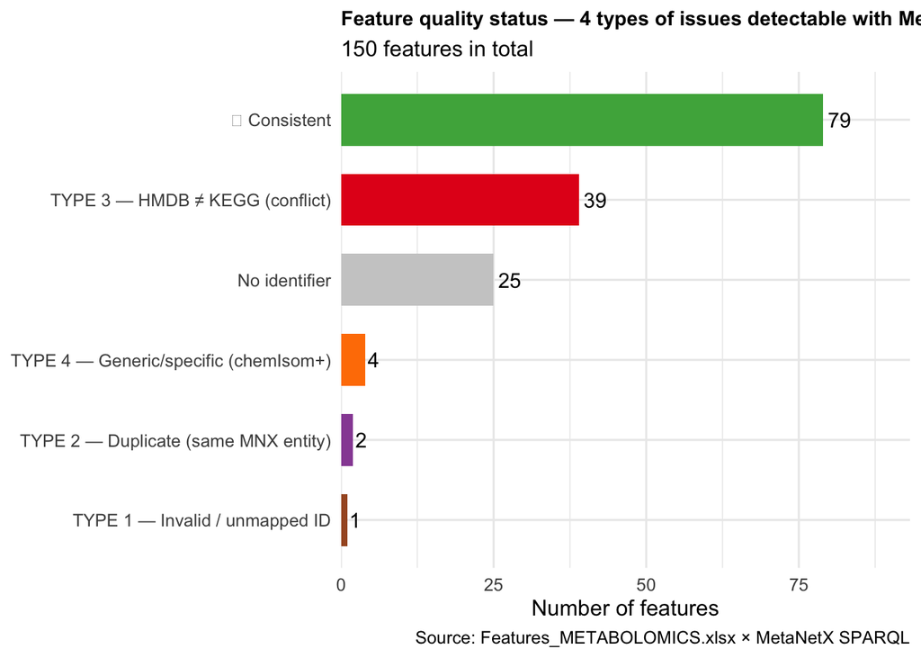

```r
# Plot
ggplot(coverage_summary, aes(x = reorder(status, n), y = n, fill = status)) +
  geom_col(width = 0.65, show.legend = FALSE) +
  geom_text(aes(label = n), hjust = -0.2, size = 4) +
  scale_fill_manual(values = c(
    "✓ Consistent"                            = "#4DAF4A",
    "TYPE 1 — Invalid / unmapped ID"          = "#A65628",
    "TYPE 2 — Duplicate (same MNX entity)"    = "#984EA3",
    "TYPE 3 — HMDB ≠ KEGG (conflict)"         = "#E41A1C",
    "TYPE 4 — Generic/specific (chemIsom+)"   = "#FF7F00",
    "No identifier"                           = "#CCCCCC",
    "Unmapped"                                = "#999999"
  )) +
  coord_flip() +
  scale_y_continuous(expand = expansion(mult = c(0, 0.18))) +
  labs(
    title    = "Feature quality status — 4 types of issues detectable with MetaNetX",
    subtitle = paste0(nrow(features), " features in total"),
    x = NULL,
    y = "Number of features",
    caption = "Source: Features_METABOLOMICS.xlsx × MetaNetX SPARQL"
  ) +
  theme_minimal(base_size = 12) +
  theme(plot.title = element_text(face = "bold", size = 11))
```

**TipReflection questions — Exercise 3**

# 5 Summary — Best practices for metabolite identification

Based on the course slides (Florence Mehl / SIB) and the exercises:

**ImportantRecommendations for metabolite identification**

**1. Distinguish the metabolite (set) from the chemical compound (individual)**  
A metabolite in a metabolic network is a *set* of molecules — it should not be confused with an individual chemical compound (e.g., a laboratory standard).

**2. Use only identifiers where name and structure are consistent**  
Check stereochemistry. Prefer databases that provide both.

**3. Specify the context of validity**  
An identifier is valid for a given analytical method, organism, and biofluid.

**4. Define a reference identifier and rank by confidence**  
Do not provide a bag of imprecise identifiers: a short, ordered list is better.

**5. Do not use MNXM identifiers as stable identifiers**  
They are not stable across releases. Use representative identifiers from source databases (ChEBI, HMDB…).

**6. Never mix generic entities and specific isomers**  
`chebi:16449` (alanine) ≠ `chebi:16977` (L-alanine) — even if they share a common MNX parent.

# 6 Documentation

1. [Introduction to SPARQL](https://sib-swiss.github.io/SPARQL_course/)
2. [MetaNetX publications](https://www.metanetx.org/mnxdoc/cite.html)